### SDS348/385 Discussion 1: R review

**Jan 21, 2015**

This discussion session reviews some of the basic concepts in R you should have encountered in Biostatistics (SDS328M). For this review, we’ll use two of R’s built-in datasets: ToothGrowth and DNase.

To begin, load the “ToothGrowth” dataset.

```r
data(ToothGrowth)

# Have a look at the data frame with the head() function
head(ToothGrowth)
```

```
##    len supp dose
## 1  4.2   VC  0.5
## 2 11.5   VC  0.5
## 3  7.3   VC  0.5
## 4  5.8   VC  0.5
## 5  6.4   VC  0.5
## 6 10.0   VC  0.5
```

This dataset contains a single numeric variable, “len” (the guinea pig tooth length), and two categorical variables, “supp” (supplement OJ or VC) and “dose” (the dosage, given in 3 levels of 0.5, 1, and 2 mg). Note that “dose” column might also be considered numeric, depending on the particular question. For now, let’s consider it to be categorical, essentially as three treatment levels. For a more comprehensive description of this dataset, you can use the `?` symbol, as you would do for a function:

```r
# Pull up the help window with an in-depth description
?ToothGrowth
```

#### Statistical testing

First, let’s perform a simple statistical analysis to answer the question, “Did guinea pigs fed vitamin C exhibit the same tooth lengths as did the guinea pigs fed orange juice?”. This question involves analyzing two groups of a single numeric variable - so, we should perform a two-sample t-test, and we will use *logical indexing* to select the VC-fed and the OJ-fed rows

```r
# Remember to use double equals sign (==) for logical indexing!
t.test(ToothGrowth$len[ToothGrowth$supp == "OJ"], ToothGrowth$len[ToothGrowth$supp == "VC"])
```

```
##
##  Welch Two Sample t-test
##
## data:  ToothGrowth$len[ToothGrowth$supp == "OJ"] and ToothGrowth$len[ToothGrowth$supp == "VC"]
## t = 1.9153, df = 55.309, p-value = 0.06063
## alternative hypothesis: true difference in means is not equal to 0
## 95 percent confidence interval:
##  -0.1710156  7.5710156
## sample estimates:
## mean of x mean of y
##  20.66333  16.96333
```

#### Plotting

##### Plotting categorical data

Next, let’s create some plots from this data. As you hopefully recall, certain plots (namely barplots) are used to plot *categorical data*, and other types of plots (e.g. histograms and boxplots) are used to plot *numeric data*.

First, let’s create a barplot displaying *counts* for the number of guinea pigs fed vitamin C and orange juice.

```r
# First, create a table containing counts for each level of the variable
supp_table <- table(ToothGrowth$supp)
supp_table
```

```
##
## OJ VC
## 30 30
```

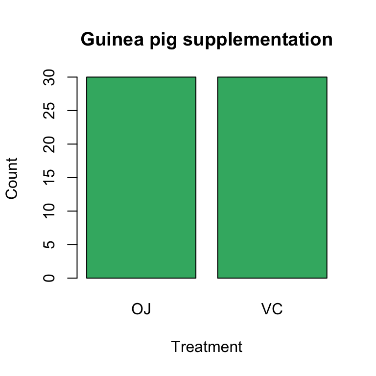

```r
# Plot the table with a title, x-axis label, y-axis label, and a custom color
barplot(supp_table, main = "Guinea pig supplementation", xlab = "Treatment", ylab = "Count", col = "mediumseagreen")
```

##### Plotting numeric data

Next, we’ll plot this dataset’s numeric variable, len, using both a histogram and boxplot.

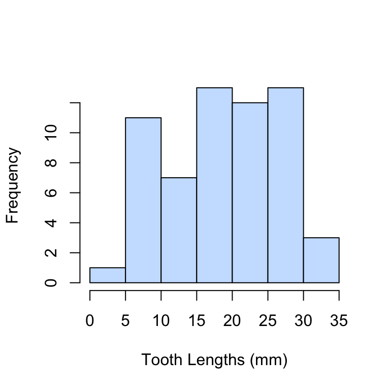

```r
# Histogram. Remove any title by specifying "" for main().
hist(ToothGrowth$len, main = "", xlab = "Tooth Lengths (mm)", col = "lightsteelblue1")
```

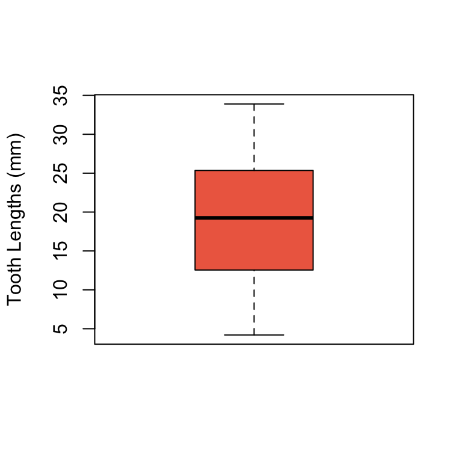

```r
# Boxplot
boxplot(ToothGrowth$len, main = "", ylab = "Tooth Lengths (mm)", col = "coral2")
```

We can also create individual boxplots, within a single plotting frame, for a given numeric variable across levels of a different categorical variable.

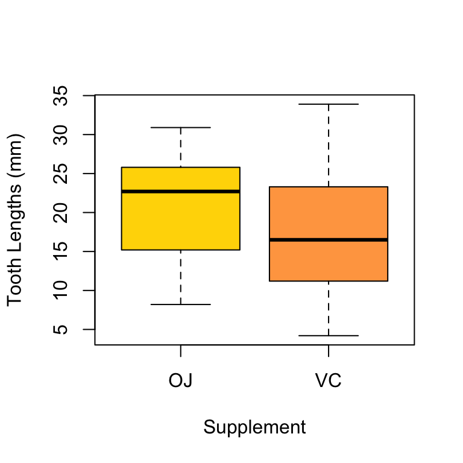

```r
# Multiple boxplots in one figure using the form "numeric_variable ~ categorical_variable"
boxplot(ToothGrowth$len ~ ToothGrowth$supp, main = "", xlab = "Supplement", ylab = "Tooth Lengths (mm)", col = c("gold", "tan1"))
```

##### Plotting multiple numeric variables

Another important type of plot is the *scatterplot*, which is used to show the relationship between two numeric variables. To create a scatterplot, we’ll use a different built-in dataset, “DNase,” as the ToothGrowth dataset contains only a single numeric variable.

```r
# Load and examine dataset
data(DNAse)
head(DNase)
```

```
##   Run       conc density
## 1   1 0.04882812   0.017
## 2   1 0.04882812   0.018
## 3   1 0.19531250   0.121
## 4   1 0.19531250   0.124
## 5   1 0.39062500   0.206
## 6   1 0.39062500   0.215
```

```r
levels(DNase$Run)
```

```
##  [1] "10" "11" "9"  "1"  "4"  "8"  "5"  "7"  "6"  "2"  "3"
```

First, let’s plot the density vs. the concentration.

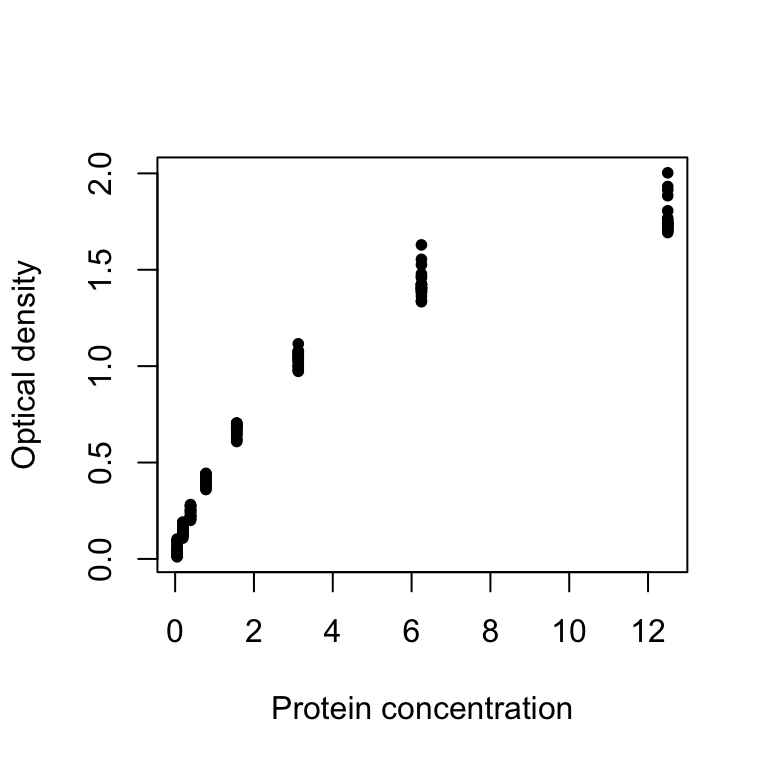

```r
# Scatterplot with solid circle points
plot(DNase$conc, DNase$density, xlab = "Protein concentration", ylab = "Optical density", pch = 20)
```

In this plot, we see that concentration and density seem to be positively correlated, although their relationship is not linear.

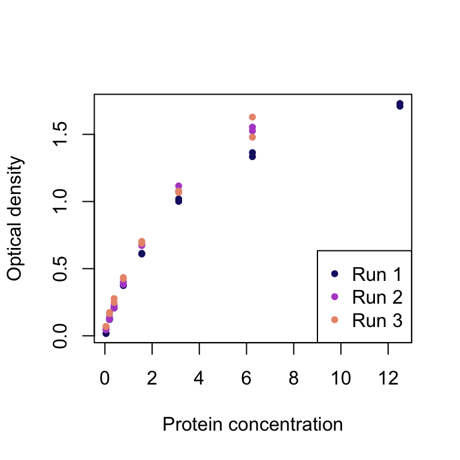

```r
# Plot points from Run 1
plot(DNase$conc[DNase$Run == "1"], DNase$density[DNase$Run == "1"], xlab = "Protein concentration", ylab = "Optical density", pch = 20, col = "midnightblue")

# Use the function "points" to add points to an existing plot
points(DNase$conc[DNase$Run == "2"], DNase$density[DNase$Run == "2"], pch = 20, col = "mediumorchid3")
points(DNase$conc[DNase$Run == "3"], DNase$density[DNase$Run == "3"], pch = 20, col = "darksalmon")


# Use the (extremely tedious!!! :( ) function "legend" to add a legend to distinguish points
legend("bottomright", pch = 20, c("Run 1", "Run 2", "Run 3"), col = c("midnightblue", "mediumorchid3", "darksalmon"))
```

Overall, this plot shows us that, although runs 1-3 have some differences, the differences are likely the result of random noise, and each replicate follows mostly the same trend (strong positive, non-linear correlation).